# Projeto Final Análise de Texto de Fontes Desestruturadas e Web

## Integrantes:

- Gabriel Yamashita
- Fábio Gerevini Canton
- Pedro Carneiro
- Stéfani Colello

## Introdução

Nos dias atuais, a tecnologia tem transformado a maneira como consumidores e empresas lidam com compras e vendas. Desta forma, o presente trabalho visa construir um tracker de preços do site da Amazon (https://www.amazon.com/), para que o consumidor possa acompanhar quando o preço diminuir. Este sistema automatizado serve para coletar e analisar mudanças nos preços de produtos, permitindo que consumidores e empresas tomem decisões mais acertivas.

Neste projeto iremos extrair os dados de preço dos celulares Samsung Galaxy S24 Ultra e Iphone 15 Pro Max, visando, além de poder visualizar os preços, comparar como diferentes produtos da mesma categoria se comportam.

## Descrição do Problema

A variação de preços é uma realidade no mercado de bens de consumo. Produtos podem sofrer mudanças de preço devido a promoções, sazonalidade, flutuações de demanda, entre outros fatores. Para consumidores, a procura pelo menor preço pode ser exaustiva e demorada. Para empresas, entender a dinâmica dos preços concorrentes é crucial para estratégias de pricing e competitividade. O problema, portanto, reside na necessidade de um sistema eficiente que monitore os preços de produtos no site (https://www.amazon.com.br/) e que notifique automaticamente, através de um link, quando um preço mais baixo é encontrado.

#### O primeiro passo é importar a bibliotecas necessarias para a análise.

```python
import os
import time
import pandas as pd
import matplotlib.pyplot as plt

# Bibliotecas para Web Scrapping
from bs4 import BeautifulSoup
from selenium import webdriver
from selenium.webdriver.chrome.service import Service
from webdriver_manager.chrome import ChromeDriverManager
from selenium.webdriver.common.by import By

# Biblioteca para Envio de Mensagem no Whatsapp
import pywhatkit as wpp
```

### Configurações de Pesquisa do Produto:

```python
CEP = '05611010'
myPhoneNumber = '+5511991982436'

minPrice = '0'
maxPrice = ''
wantedPrice = 8_000

searchTime = 12 # em horas
```

### Iniciando Webdriver do Chrome

```python
# Pega Perfil de Navagação do Chrome
path = '/'.join(os.getcwd().split('\\')[:3])
CHROME_PROFILE_PATH = f'{path}/AppData/Local/Google/Chrome/User Data/WebScrapping/Projeto'

# Carrega Perfil no Webdriver
options = webdriver.ChromeOptions()
options.add_argument(CHROME_PROFILE_PATH)

# Inicia Webdriver
wd = webdriver.Chrome(service=Service(ChromeDriverManager().install()), options=options)
```

```python
wd.implicitly_wait(15)
```

### Atualiza para Endereço de Compra:

```python
# Abre Amazon
wd.get("https://amazon.com.br")
time.sleep(5)

# Procura por 'Escolha sua localização'
wd.find_element(By.ID, "nav-global-location-popover-link").click()

# Separa CEP
CEP1 = CEP[:-3]
CEP2 = CEP[-3:]

# Preenche Primeira Parte do CEP
cep1_field = wd.find_element(By.ID, "GLUXZipUpdateInput_0")
cep1_field.send_keys(CEP1)
time.sleep(2)

# Preenche Segunda Parte do CEP
cep2_field = wd.find_element(By.ID, "GLUXZipUpdateInput_1")
cep2_field.send_keys(CEP2)
time.sleep(2)

# Confirma CEP
confirm_element = wd.find_element(By.XPATH, '//*[@id="GLUXZipUpdate"]/span/input')
confirm_element.click()
```

### Cria Dataframe com Nome do Produto, Patrocínio, Preço e URL:

```python
def getPandaDfForSearchResults(searchResultsPage):
    rows=[]
    for result in searchResultsPage:
        title = result.find("span", {"class": "a-text-normal"}) # título do produto
        sponsored = result.find("span", {"class": "a-color-base"}, string="Sponsored") # patrocínio do produto
        price = result.find("span", {"class": "a-price-whole"}) # preço do produto
        url = result.find("a", {"class": "a-link-normal"}) # url do produto

        if price:
            # Cria Linha do Dataframe
            row = [title.text, bool(sponsored), price.text, "https://amazon.com.br/" + url['href']]
            rows.append(row)

    # Cria Dataframe e Retorna
    df = pd.DataFrame.from_records(rows, columns=["Title", "Sponsored", "Price", "URL"])

    return df
```

### Procura por Informações nas Páginas do Produto:

```python
def getSearchResultsForPage(url):
    wd.get(url) # abre link de procura

    nextPageCssClasses = [] # lista para checar próxima página
    nextPageLink = wd.find_element(By.CLASS_NAME, "s-pagination-next") # procura por botão de próxima página

    df_all_search_results = pd.DataFrame(columns=["Title", "Sponsored", "Price"]) # cria dataframes de resultados

    # Procura pelo Botão Desabilitado de Próxima Página
    while not "s-pagination-disabled" in nextPageCssClasses:
        # Puxa as Informações da Página
        soup = BeautifulSoup(wd.page_source)
        searchResultsPage = soup.findAll("div", {"data-component-type": "s-search-result"})
        df = getPandaDfForSearchResults(searchResultsPage)

        # Junta o Dataframe da Página com o Geral
        toConcat = [df for df in [df_all_search_results, df] if not df.empty]
        df_all_search_results = pd.concat(toConcat, ignore_index=True)

        # Vai para a Próxima Página
        nextPageLink.click()
        nextPageLink = wd.find_element(By.CLASS_NAME, "s-pagination-next")
        nextPageCssClasses = nextPageLink.get_attribute("class").split()
        time.sleep(2)

    # Termina Loop
    if "s-pagination-disabled" in nextPageCssClasses:
        print("Reached last page of search results")

    # Tratando Preços
    df_all_search_results['Price'] = df_all_search_results['Price'].str.replace(",","")
    df_all_search_results['Price'] = df_all_search_results['Price'].str.replace(".","")
    df_all_search_results['Price'] = df_all_search_results['Price'].astype(float)

    return df_all_search_results
```

### Função para Mandar Mensagem no Whatsapp:

```python
def sendWhatsAppMessage(df):
    # Itera no Dataframe
    for index, graphicsCardRow in df.iterrows():
        # Acessa Link do Produto
        wd.get(graphicsCardRow.URL)
        # print(graphicsCardRow.URL)

        # Checa Existência da Pasta e Cria
        if not os.path.exists(f'./Screenshot'):
            os.mkdir(f'./Screenshot')

        # Salva Screenshot da Página para Envio
        screenshotFilepath = f"./Screenshot/screenshot_{index}.png"
        wd.save_screenshot(screenshotFilepath)

        # Envia Mensagem no Whatsapp
        wpp.sendwhats_image(myPhoneNumber, screenshotFilepath, graphicsCardRow.URL, tab_close=True)
```

### Envio de Mensagens e Raspagem de Dados, Focado de um Preço Desejado:

```python
while True:
    # Procura por Produto
    df = getSearchResultsForPage(f"https://www.amazon.com.br/s?k=galaxy+s24&__mk_pt_BR=%C3%85M%C3%85%C5%BD%C3%95%C3%91&crid=3KKL3MYHATJNK&qid=1717368500&rnid=16245552011&sprefix=galaxy+s2%2Caps%2C389&ref=sr_nr_p_36_0_0&low-price={minPrice}&high-price={maxPrice}")

    # Filtra Produtos Encontrados, por Palavra e Preço
    df_query = df[(df.Title.str.contains("Ultra")) & (df.Price <= wantedPrice)]

    # Manda Mensagem dos Produtos Encontrados
    if (not df_query.empty):
        print("Found products that I want to buy")
        sendWhatsAppMessage(df_query)
        break

    else:
        # Espera por Tempo Desejado para Próxima Consulta
        time.sleep(searchTime * 60 * 60)
```

## Search "Galaxy S24 Ultra":

```python
search_S24 = getSearchResultsForPage(f"https://www.amazon.com.br/s?k=galaxy+s24&__mk_pt_BR=%C3%85M%C3%85%C5%BD%C3%95%C3%91&crid=3KKL3MYHATJNK&qid=1717368500&rnid=16245552011&sprefix=galaxy+s2%2Caps%2C389&ref=sr_nr_p_36_0_0&low-price={minPrice}&high-price={maxPrice}")
search_S24.head(10)
```

```
Reached last page of search results
```

|  | Title | Sponsored | Price | URL |
| --- | --- | --- | --- | --- |
| 0 | Smartphone Samsung Galaxy S24, Galaxy AI, Self... | False | 5699.0 | https://amazon.com.br//Smartphone-Samsung-Gala... |
| 1 | Smartphone Samsung Galaxy S24 Ultra, Galaxy AI... | False | 8620.0 | https://amazon.com.br//Smartphone-Samsung-Gala... |
| 2 | Smartphone Samsung Galaxy S24 Ultra, Galaxy AI... | False | 7899.0 | https://amazon.com.br//Smartphone-Samsung-Gala... |
| 3 | Smartphone Samsung Galaxy S24+, Galaxy AI, Sel... | False | 6649.0 | https://amazon.com.br//Smartphone-Samsung-Gala... |
| 4 | Smartphone Samsung Galaxy S24 Ultra, Galaxy AI... | False | 7562.0 | https://amazon.com.br//Smartphone-Samsung-Gala... |
| 5 | Smartphone Samsung Galaxy S24 Ultra, Galaxy AI... | False | 7698.0 | https://amazon.com.br//Smartphone-Samsung-Gala... |
| 6 | Smartphone Samsung Galaxy S24 Ultra, Galaxy AI... | False | 8057.0 | https://amazon.com.br//Smartphone-Samsung-Gala... |
| 7 | Samsung Galaxy S24 5G SM-S921B Dual Sim 128 GB... | False | 5694.0 | https://amazon.com.br//Samsung-Galaxy-SM-S921B... |
| 8 | Smartphone Samsung Galaxy S24+, Galaxy AI, Sel... | False | 7270.0 | https://amazon.com.br//Smartphone-Samsung-Gala... |
| 9 | Smartphone Samsung Galaxy S24 Ultra, Galaxy AI... | False | 9999.0 | https://amazon.com.br//Smartphone-Samsung-Qu%C... |

```python
if not os.path.exists(f'./Dataframes'):
        os.mkdir(f'./Dataframes')

search_S24.to_excel("./Dataframes/S24.xlsx", index=False)
```

## Search "Iphone 15 Pro Max":

```python
search_iphone_15 = getSearchResultsForPage(f"https://www.amazon.com.br/s?k=Iphone+15+pro+max&__mk_pt_BR=%C3%85M%C3%85%C5%BD%C3%95%C3%91&crid=3H2LQPQLRB3PL&qid=1717369579&rnid=16245552011&sprefix=iphone+15+pro+ma%2Caps%2C256&ref=sr_nr_p_36_0_0&low-price={minPrice}&high-price={maxPrice}")
search_iphone_15.head(10)
```

```
Reached last page of search results
```

|  | Title | Sponsored | Price | URL |
| --- | --- | --- | --- | --- |
| 0 | Apple iPhone 15 Pro Max (256 GB) — Titânio nat... | False | 7899.0 | https://amazon.com.br//sspa/click?ie=UTF8&spc=... |
| 1 | Apple iPhone 15 Pro (512 GB) — Titânio branco | False | 8999.0 | https://amazon.com.br//sspa/click?ie=UTF8&spc=... |
| 2 | Apple iPhone 15 Pro Max (256 GB) — Titânio Azul | False | 9958.0 | https://amazon.com.br//Apple-iPhone-Pro-Max-25... |
| 3 | Apple iPhone 15 Pro (128) — Titânio natural | False | 6967.0 | https://amazon.com.br//Apple-iPhone-15-Pro-128... |
| 4 | Apple iPhone 15 (128 GB) — Preto | False | 4848.0 | https://amazon.com.br//Apple-iPhone-15-128-GB/... |
| 5 | Apple iPhone 14 (128 GB) – Estelar | False | 3869.0 | https://amazon.com.br//Apple-iPhone-14-128-GB/... |
| 6 | ESR Capa para iPhone 15 Pro Max, compatível co... | False | 198.0 | https://amazon.com.br//ESR-compat%C3%ADvel-res... |
| 7 | Apple iPhone 13 (128 GB) - Meia-noite | False | 3598.0 | https://amazon.com.br//Apple-iPhone-13-128-GB-... |
| 8 | Apple iPhone 15 Plus (256 GB) — Rosa | False | 9099.0 | https://amazon.com.br//Apple-iPhone-15-Plus-25... |
| 9 | Apple iPhone 11 (64 GB) Preto | False | 2789.0 | https://amazon.com.br//Iphone-Apple-Preto-64gb... |

```python
if not os.path.exists(f'./Dataframes'):
        os.mkdir(f'./Dataframes')

search_iphone_15.to_excel("./Dataframes/Iphone15_ProMax.xlsx", index=False)
```

## Análise:

```python
S24_describe = search_S24.describe()
iphone_describe = search_iphone_15.describe()

S24_describe, iphone_describe
```

```
(              Price
 count    167.000000
 mean    1376.520958
 std     2282.722138
 min       15.000000
 25%      104.000000
 50%      189.000000
 75%     1594.000000
 max    10939.000000,
               Price
 count    109.000000
 mean    1559.577982
 std     2799.575405
 min       12.000000
 25%       99.000000
 50%      199.000000
 75%     1165.000000
 max    10499.000000)
```

### Ao analisar o describe acima, algumas informações e ressalvas podem ser feitas:

**Média**: Ao analisar a média dos preços do Samsung Galaxy S24 Ultra e Iphone 15 Pro Max podemos perceber que o samsung possui produtos com valores mais baixos.

**Desvio Padrão**: Em relação ao desvio padrão, percebemos que o Iphone 15 Pro Max possui uma maior discrepância nos preços de seus produtos, podendo ser devido a uma menor quantidade de dados quando em comparação ao celular samsung.

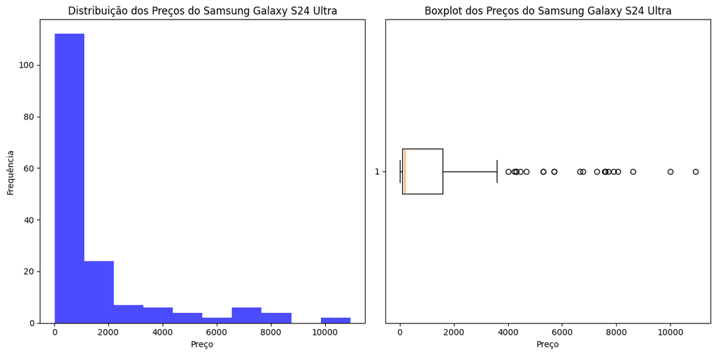

```python
plt.figure(figsize=(12, 6))

plt.subplot(1, 2, 1)
plt.hist(search_S24['Price'], bins=10, alpha=0.7, color='blue')
plt.title('Distribuição dos Preços do Samsung Galaxy S24 Ultra')
plt.xlabel('Preço')
plt.ylabel('Frequência')

plt.subplot(1, 2, 2)
plt.boxplot(search_S24['Price'], vert=False)
plt.title('Boxplot dos Preços do Samsung Galaxy S24 Ultra')
plt.xlabel('Preço')

plt.tight_layout()
plt.show()
```

Pode-se perceber nos dois gráficos uma grande concentração de dados em valores mais baixos, com pequena variação entre os valores centrais e uma grande quantidade de outliers. Isso se da por, no momento da extração dos dados com o input "Samsung Galaxy S24 Ultra", recebermos dados de produtos que não são celulares, mas sim acessórios, que detém valores muito inferiores em relação ao aparelho procurado.

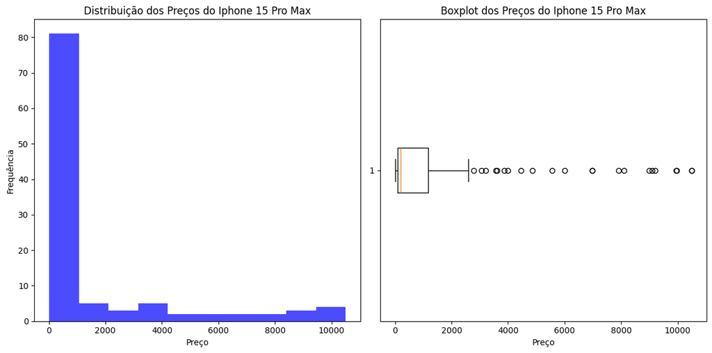

```python
plt.figure(figsize=(12, 6))

plt.subplot(1, 2, 1)
plt.hist(search_iphone_15['Price'], bins=10, alpha=0.7, color='blue')
plt.title('Distribuição dos Preços do Iphone 15 Pro Max')
plt.xlabel('Preço')
plt.ylabel('Frequência')

plt.subplot(1, 2, 2)
plt.boxplot(search_iphone_15['Price'], vert=False)
plt.title('Boxplot dos Preços do Iphone 15 Pro Max')
plt.xlabel('Preço')

plt.tight_layout()
plt.show()
```

Os gráficos para a análise de dispersão de dados do Iphone 15 Pro Max é parecida com os gráficos do Samsung Galaxy S24 Ultra. Possui uma grande concentração de dados em valores mais baixos, com baixa variação entre os dados centrais com um elevado número de outliers. Isso se da novamente por, quando realizada a extração com o input "Iphone 15 Prox Max", recebermos também dados de acessórios para o celular, não somente do aparelho.

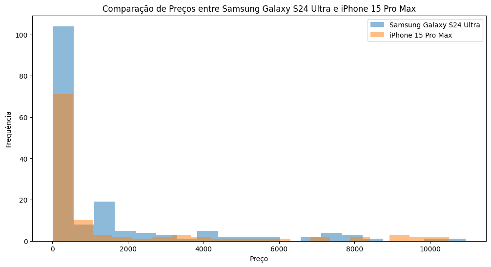

```python
plt.figure(figsize=(12, 6))
plt.hist(search_S24['Price'], bins=20, alpha=0.5, label='Samsung Galaxy S24 Ultra')
plt.hist(search_iphone_15['Price'], bins=20, alpha=0.5, label='iPhone 15 Pro Max')
plt.xlabel('Preço')
plt.ylabel('Frequência')
plt.title('Comparação de Preços entre Samsung Galaxy S24 Ultra e iPhone 15 Pro Max')
plt.legend(loc='upper right')
plt.show()
```

Quando realizado um histograma dos preços da busca pelos celulares, pode-se perceber que eles tem compartamentos muito parecidos, com uma grande quantidade de dados com valores inferiores devido a aparição de acessórios para o produto, e poucos dados com valores elevados, que representam os celulares de fato.

```python
top_5_expensive_S24 = search_S24.nlargest(5, 'Price')
top_5_expensive_S24
```

|  | Title | Sponsored | Price | URL |
| --- | --- | --- | --- | --- |
| 44 | Smartphone Samsung Galaxy S24 Ultra, Galaxy AI... | False | 10939.0 | https://amazon.com.br//Smartphone-Samsung-Qu%C... |
| 9 | Smartphone Samsung Galaxy S24 Ultra, Galaxy AI... | False | 9999.0 | https://amazon.com.br//Smartphone-Samsung-Qu%C... |
| 1 | Smartphone Samsung Galaxy S24 Ultra, Galaxy AI... | False | 8620.0 | https://amazon.com.br//Smartphone-Samsung-Gala... |
| 6 | Smartphone Samsung Galaxy S24 Ultra, Galaxy AI... | False | 8057.0 | https://amazon.com.br//Smartphone-Samsung-Gala... |
| 2 | Smartphone Samsung Galaxy S24 Ultra, Galaxy AI... | False | 7899.0 | https://amazon.com.br//Smartphone-Samsung-Gala... |

```python
top_5_expensive_iphone_15 = search_iphone_15.nlargest(5, 'Price')
top_5_expensive_iphone_15
```

|  | Title | Sponsored | Price | URL |
| --- | --- | --- | --- | --- |
| 25 | Apple iPhone 13 Pro (256 GB) - Azul Sierra | False | 10499.0 | https://amazon.com.br//Apple-iPhone-Pro-256-GB... |
| 31 | Apple iPhone 14 Pro Max (128 GB) – Dourado | False | 10499.0 | https://amazon.com.br//Apple-iPhone-Pro-Max-12... |
| 2 | Apple iPhone 15 Pro Max (256 GB) — Titânio Azul | False | 9958.0 | https://amazon.com.br//Apple-iPhone-Pro-Max-25... |
| 16 | Apple iPhone 13 Pro Max (128 GB) - Verde-alpino | False | 9939.0 | https://amazon.com.br//Apple-iPhone-Pro-Max-12... |
| 20 | Apple iPhone 14 (256 GB) – Estelar | False | 9199.0 | https://amazon.com.br//Apple-iPhone-14-256-GB/... |

Na comparação dos maiores preços por produto buscado, onde econtramos os aparelhos celulares de fato, entedemos que eles se encontram na mesma categoria por possuirem valores muito parecidos.

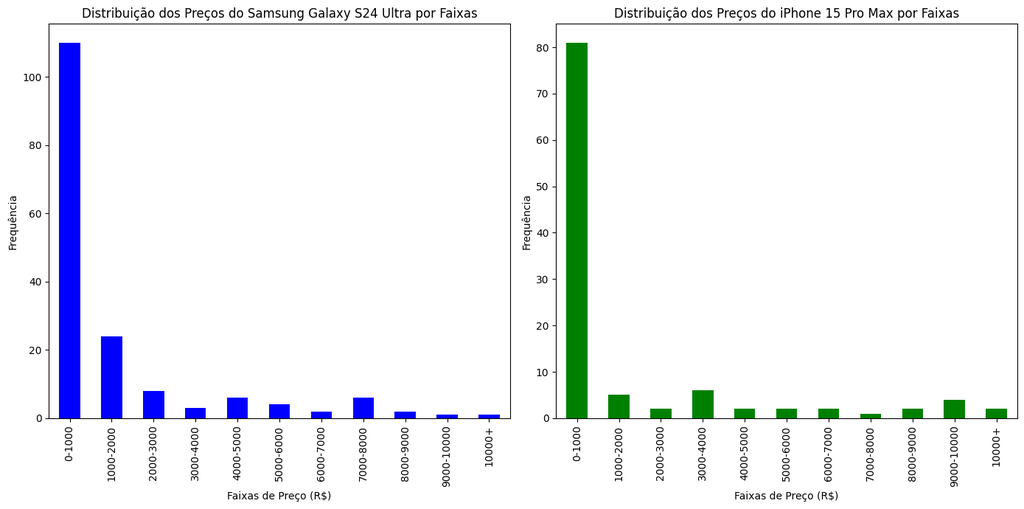

```
(Price
 0-1000        110
 1000-2000      24
 2000-3000       8
 3000-4000       3
 4000-5000       6
 5000-6000       4
 6000-7000       2
 7000-8000       6
 8000-9000       2
 9000-10000      1
 10000+          1
 Name: count, dtype: int64,
 Price
 0-1000        81
 1000-2000      5
 2000-3000      2
 3000-4000      6
 4000-5000      2
 5000-6000      2
 6000-7000      2
 7000-8000      1
 8000-9000      2
 9000-10000     4
 10000+         2
 Name: count, dtype: int64)
```

```python
bins = [0, 1000, 2000, 3000, 4000, 5000, 6000, 7000, 8000, 9000, 10000, float('inf')]
labels = ['0-1000', '1000-2000', '2000-3000', '3000-4000', '4000-5000', '5000-6000', '6000-7000', '7000-8000', '8000-9000', '9000-10000', '10000+']

galaxy_price_groups = pd.cut(search_S24['Price'], bins=bins, labels=labels, right=False)
iphone_price_groups = pd.cut(search_iphone_15['Price'], bins=bins, labels=labels, right=False)

galaxy_price_counts = galaxy_price_groups.value_counts().sort_index()
iphone_price_counts = iphone_price_groups.value_counts().sort_index()

plt.figure(figsize=(14, 7))

plt.subplot(1, 2, 1)
galaxy_price_counts.plot(kind='bar', color='blue')
plt.title('Distribuição dos Preços do Samsung Galaxy S24 Ultra por Faixas')
plt.xlabel('Faixas de Preço (R$)')
plt.ylabel('Frequência')

plt.subplot(1, 2, 2)
iphone_price_counts.plot(kind='bar', color='green')
plt.title('Distribuição dos Preços do iPhone 15 Pro Max por Faixas')
plt.xlabel('Faixas de Preço (R$)')
plt.ylabel('Frequência')

plt.tight_layout()
plt.show()

galaxy_price_counts, iphone_price_counts
```

Ao separar os produtos por faixa de preço percebemos novamente a grande quantidade de dados com valores baixos para ambas as buscas devido a aparição de acessórios para celulares que apareçem na extração.

## Conclusão:

A implementação de um tracker de preços não só beneficia consumidores, proporcionando economia e eficiência, como também oferece às empresas uma ferramenta poderosa para análise de mercado e ajuste de estratégias. A metodologia descrita mostra-se eficaz para a coleta, análise e notificação de preços, promovendo uma maior transparência e competitividade no mercado. Esta análise preliminar destaca a necessidade e os benefícios de um sistema automatizado de monitoramento de preços, incentivando a adoção de tecnologias que proporcionem eficiência e competitividade no mercado de consumo. Além disso, com a análise dos preços encontrados, podemos inferir que os preços dos celulares (utilizando a premissa de que são aqueles com valores acima de 4000 reais) possuem comportamentos parecidos, visto que são da mesma categoria. Ademais, os outliers encontrados são devido à existência de acessórios para ambos os produtos.